# Análise exploratória

## Imports, definição de funções e carregamento dos dados

```python
import matplotlib.pyplot as plt
import nltk
from nltk import ngrams
import os
import pandas as pd
from b_preparar.preparador import Preparador
from _common import util

def mostrar_ngrams_frequentes(df, coluna, n):
	coluna_preparada = coluna + '_preparado'
	todas_as_palavras = [palavra for palavras in df[coluna_preparada] for palavra in palavras]
	n_grams = ngrams(todas_as_palavras, n)
	nltk_freq_distr = nltk.FreqDist(n_grams)
	most_common = nltk_freq_distr.most_common(20)
	plt.barh(range(len(most_common)),[val[1] for val in most_common], align='center')
	plt.yticks(range(len(most_common)), [val[0] for val in most_common])
	plt.show()

def mostrar_registros_contendo_str_apos_preparacao(df, coluna, ngram_as_str, coluna_a_exibir = None):
	if coluna_a_exibir == None:
		coluna_a_exibir = coluna
	coluna_preparada_str = coluna + '_preparado_str'
	return df.loc[df[coluna_preparada_str].str.contains(ngram_as_str)][coluna_a_exibir]

def calcular_tamanho(df, coluna, force = False):
	coluna_tamanho = 'tamanho_' + coluna
	if not coluna_tamanho in df or force:
		df['tamanho_' + coluna] = [len(c) for c in df[coluna]]
	return coluna_tamanho

def mostrar_histograma(df, coluna):
	coluna_tamanho = calcular_tamanho(df, coluna)
	plt.hist(df[coluna_tamanho])
	plt.show()

def mostrar_registros_com_tam_menor_q(df, coluna, tam):
	coluna_tamanho = calcular_tamanho(df, coluna)
	return df.loc[df[coluna_tamanho] < tam][coluna]

def mostrar_registros_com_tam_maior_q(df, coluna, tam):
	coluna_tamanho = calcular_tamanho(df, coluna)
	return df.loc[df[coluna_tamanho] > tam][coluna]

pd.set_option('display.max_rows', 20)
pd.set_option('display.max_colwidth', 2000)

noticias_df = util.carregar_todas_as_noticias()
Preparador().preparar(noticias_df, remover_conteudo_inutil = False) # Não remover pq queremos justamente analisar
```

```
Preparando titulo
Preparando resumo
```

## Análise de palavras e ngrams

### Palavras mais frequentes do título

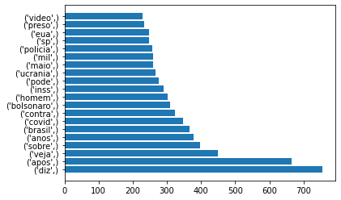

```python
mostrar_ngrams_frequentes(noticias_df, 'titulo', 1)
```

Das palavras muito frequentes acima, "veja" e "video" parecem indicar títulos de matérias desprovidas de utilidade. Necessário analisar os bigrams.

### Bigrams mais frequentes do título

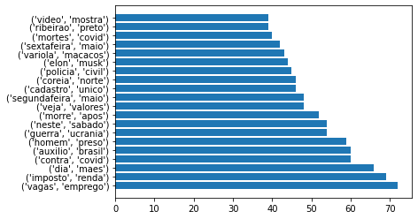

```python
mostrar_ngrams_frequentes(noticias_df, 'titulo', 2)
```

Dos bigrams acima, parece estranho "vagas emprego", "homem preso", "morre apos", "neste sabado", "veja valores", "segundafeira maio" (ou "sextafeira maio") e "video mostra" constarem entre os mais frequentes. Verificando cada expressão dessas...

#### "vagas emprego"

```python
mostrar_registros_contendo_str_apos_preparacao(noticias_df, 'titulo', 'vagas emprego')
```

```
159      Confira as vagas de emprego do Sine em Macapá ...
134      Veja as vagas de emprego disponíveis em Petrol...
385      158 vagas de emprego são ofertadas pelo Sine M...
794       100 vagas de emprego: Coca-Cola está contratando
911      Vagas de emprego na área de tecnologia aumenta...
                               ...
9890     Veja as vagas de emprego disponíveis em Petrol...
9869     Sine de Porto Velho oferta 151 vagas de empreg...
10180    Veja as vagas de emprego disponíveis em Petrol...
10169    Sine de Porto Velho oferta 161 vagas de empreg...
10651    Sine Maceió oferta mais de 200 vagas de empreg...
Name: titulo, Length: 72, dtype: object
```

**Decisão:** Algumas das matérias contendo o bigram "vagas emprego" parecem ser publicadas diariamente, e não tratar de assuntos específicos, cuja cobertura possa variar com o tempo. É necessário analisar os trigrams para decidir manter ou eliminar.

#### "homem preso"

```python
mostrar_registros_contendo_str_apos_preparacao(noticias_df, 'titulo', 'homem preso')
```

```
183      Homem é preso pela Polícia Civil por suspeita ...
119      Magnata chinês Jack Ma é confundido com homem ...
106      Homem é preso por manter companheira em cárcer...
430      Homem é preso após confessar assassinato de ex...
474      Homem é preso por agredir e manter namorada em...
                               ...
9114     Homem é preso em flagrante por agredir mulher ...
9273     Homem é preso suspeito de agredir a mulher grá...
9384     Homem é preso com tabletes de crack, cocaína e...
9477       Homem é preso após chamar segurança de "macaco"
10627    Homem é preso por violência doméstica e posse ...
Name: titulo, Length: 58, dtype: object
```

**Decisão:** ignorar "homem preso" pois parece apenas uma expressão frequente, em notícias legítimas

#### "morre apos"

```python
mostrar_registros_contendo_str_apos_preparacao(noticias_df, 'titulo', 'morre apos')
```

```
589      Caso Lucilene: possível testemunha morre após ...
602      Motorista morre após ter carro parado no acost...
1371     Homem morre após ser baleado na Prainha em Cuiabá
1520     Jovem morre após perder o controle de moto e s...
2126     Jovem de 17 anos morre após bater moto em cami...
                               ...
9883     Motociclista morre após colidir com caminhão n...
10417    Caminhoneiro morre após bater na traseira de o...
10413    Jovem de 20 anos morre após perder o controle ...
10669    Motociclista morre após colidir contra búfalo ...
10647    Homem morre após tentar entrar armado em bar, ...
Name: titulo, Length: 52, dtype: object
```

**Decisão:** ignorar "morre apos" pois parece apenas uma expressão frequente, em notícias legítimas

#### "neste sabado"

```python
mostrar_registros_contendo_str_apos_preparacao(noticias_df, 'titulo', 'neste sabado')
```

```
419      Carimbó tradicional e contemporâneo é celebrad...
386      Artur Nogueira recebe festival gratuito de Hip...
1052     'Recitrônico': projeto recebe equipamentos ele...
1285     Espetáculo infantil é promovido pelo Museu da ...
1492     Unidade de saúde da Vila Nova Jundiapeba, em M...
                               ...
8780     Mega-Sena sorteia neste sábado prêmio acumulad...
8956     Enem 2022: inscrições terminam neste sábado (2...
9035     'Ytalo & Maciel', 'Malla 100 Alça' e 'Jonathan...
10148    Campanha do Agasalho tem Dia 'D' neste sábado ...
10147    Ação social oferece diversos atendimentos grat...
Name: titulo, Length: 54, dtype: object
```

**Decisão:** ignorar "neste sabado" pois parece apenas uma expressão frequente, em notícias legítimas

#### "veja valores"

```python
mostrar_registros_contendo_str_apos_preparacao(noticias_df, 'titulo', 'veja valores')
```

```
1948    Bradesco: ações fecham em alta de 1,97% nesta ...
1947    Vale: ação fecha em queda de 0,49% nesta sexta...
1943    Pão de Açúcar: ação tem maior baixa em mais de...
1922    Itaú Unibanco: ação fecha em alta de 1,89% nes...
1917    Magazine Luiza: ação fecha em queda de 3,85% n...
                              ...
6952    Banco do Brasil: ação fecha em alta de 0,77% n...
6951    Via: ação fecha em alta de 5,76% nesta segunda...
8865    Embraer: ação fecha em queda de 1,86% nesta se...
8863    Via: ação fecha em alta de 0,33% nesta sexta; ...
8866    Banco do Brasil: ação fecha em alta de 3,64% n...
Name: titulo, Length: 48, dtype: object
```

**Decisão:** remover as matérias que contêm o bigram "veja valores" no título pois parecem ser publicadas diariamente, e não tratar de assuntos específicos, cuja cobertura possa variar com o tempo.

#### "segundafeira maio"

```python
mostrar_registros_contendo_str_apos_preparacao(noticias_df, 'titulo', 'segundafeira maio')
```

```
2841    VÍDEOS: Bom Dia Paraná de segunda-feira, 9 de ...
2836    VÍDEOS: Bom Dia Cidade Campinas de segunda-fei...
2820    VÍDEOS: assista às notícias da Rede Clube de s...
2817    VÍDEOS: Bom Dia Cidade Piracicaba de segunda-f...
2818    VÍDEOS: Bom Dia SP de segunda-feira, 9 de maio...
                              ...
6984    VÍDEOS: Jornal do Acre 2ª edição - AC de segun...
9536    VÍDEOS: Bom Dia Cidade Sul de Minas de segunda...
9535    VÍDEOS: Bom Dia SP de segunda-feira, 23 de mai...
9524    VÍDEOS: Bom Dia Alagoas de segunda-feira, 23 d...
9729     VÍDEOS: MG1 de segunda-feira, 23 de maio de 2022
Name: titulo, Length: 48, dtype: object
```

**Decisão:** remover as matérias cujo título começa com "VÍDEOS:" pois parecem ser publicadas diariamente, e não tratar de assuntos específicos, cuja cobertura possa variar com o tempo.

#### "video mostra"

```python
mostrar_registros_contendo_str_apos_preparacao(noticias_df, 'titulo', 'video mostra')
```

```
197      Vídeo mostra brasileiros suspeitos de tráfico ...
870      Você viu? Horário de funcionamento do comércio...
1078      Elden Ring: vídeo mostra 15 minutos do mod de VR
1330     Vídeo mostra assistente social dizendo que méd...
1444     Vídeo mostra momento em que policiais civis em...
                               ...
8539     VÍDEO mostra como míssil destrói centro cultur...
8619     Vídeo mostra fuga de miliciano de boate e PM c...
8948     Vídeo mostra coronel da PM matando engenheiro ...
10124    Vídeo mostra homem pendurado em caminhão em av...
10121    Vídeo mostra momento em que criança de 2 anos ...
Name: titulo, Length: 39, dtype: object
```

**Decisão:** ignorar "video mostra" pois parece que as matérias que contêm esse bigram no título tratam de assuntos específicos.

### Trigrams mais frequentes do título

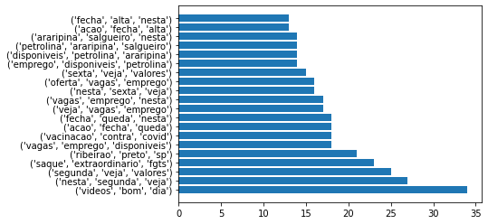

```python
mostrar_ngrams_frequentes(noticias_df, 'titulo', 3)
```

Dos trigrams acima (sem reconsiderar aqui os que já teriam sido eliminados a partir da análise feita anteriormente), parece estranho as expressões "araripina salgueiro nesta", "petrolina araripina salgueiro", "disponiveis petrolina araripina", "emprego disponiveis petrolina", "ofertas vagas emprego", "vagas emprego nesta", "veja vagas emprego" estarem entre as mais frequentes.

Verificando essas expressões...

#### "veja vagas emprego", "vagas emprego nesta", "emprego disponiveis petrolina", "disponiveis petrolina araripina", "petrolina araripina salgueiro" e "araripina salgueiro nesta"

```python
mostrar_registros_contendo_str_apos_preparacao(noticias_df, 'titulo', 'veja vagas emprego')
```

```
134      Veja as vagas de emprego disponíveis em Petrol...
875      Veja as vagas de emprego disponíveis em Petrol...
2851     Veja as vagas de emprego disponíveis em Petrol...
3040     Classificados do Edimilson: veja as vagas de e...
3807     Veja as vagas de emprego disponíveis em Petrol...
4614     Veja as vagas de emprego disponíveis em Petrol...
4972     Veja as 158 vagas de emprego disponíveis em Pe...
5605     Veja as vagas de emprego disponíveis em Petrol...
6252     Veja as 171 vagas de emprego disponíveis em Pe...
6450     Classificados do Edimilson: veja as vagas de e...
7146     Veja as vagas de emprego disponíveis em Petrol...
7850     Veja as vagas de emprego disponíveis em Petrol...
8198     Veja as vagas de emprego disponíveis em Petrol...
9540     Veja as vagas de emprego disponíveis em Petrol...
9724     Classificados do Edimilson: veja as vagas de e...
9890     Veja as vagas de emprego disponíveis em Petrol...
10180    Veja as vagas de emprego disponíveis em Petrol...
Name: titulo, dtype: object
```

**Decisão:** remover as matérias cujo título contém a expressão regular "veja .*vagas de emprego", pois parecem ser publicadas diariamente, e não tratar de assuntos específicos, cuja cobertura possa variar com o tempo.

#### "oferta vagas emprego"

```python
mostrar_registros_contendo_str_apos_preparacao(noticias_df, 'titulo', 'oferta vagas emprego')
```

```
1054     Eletricista, consultor de vendas: Sine em RR o...
1222     Sine de Porto Velho oferta mais de 35 vagas de...
2565     Sine Maceió oferta 152 vagas de emprego para t...
3065     Sine de Porto Velho oferta mais de 30 vagas de...
3788     Atendente de padaria, operador de caixa: Sine ...
5288     Sine Maceió oferta vagas de emprego nas áreas ...
6239     Sine de Porto Velho oferta 140 vagas de empreg...
6543     Restaurante oferta 100 vagas de emprego em For...
6616     Sine oferta 76 vagas de emprego em Ivaiporã ne...
7842     Sine de Porto Velho oferta 141 vagas de empreg...
9425     Sine Maceió oferta mais de 100 vagas de empreg...
9510     Sine João Pessoa oferta mais de 100 vagas de e...
9505     Sine de Campina Grande oferta 135 vagas de emp...
9869     Sine de Porto Velho oferta 151 vagas de empreg...
10169    Sine de Porto Velho oferta 161 vagas de empreg...
10651    Sine Maceió oferta mais de 200 vagas de empreg...
Name: titulo, dtype: object
```

**Decisão:** remover as matérias que contêm o trigram "oferta vagas emprego" no título pois parecem ser publicadas diariamente, e não tratar de assuntos específicos, cuja cobertura possa variar com o tempo.

### Palavras mais frequentes do resumo

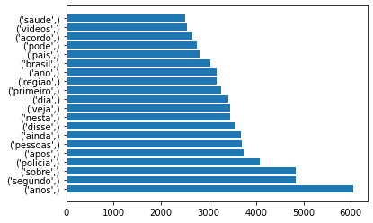

```python
mostrar_ngrams_frequentes(noticias_df, 'resumo', 1)
```

Das palavras muito frequentes acima, "veja" e "videos" parecem sugerir resumos desprovidos de utilidade. Necessário analisar os bigrams.

### Bigrams mais frequentes do resumo

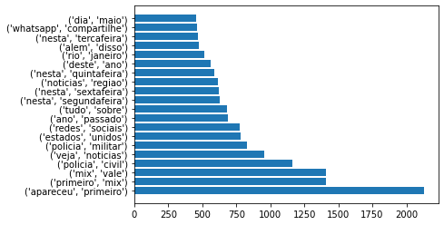

```python
mostrar_ngrams_frequentes(noticias_df, 'resumo', 2)
```

Dos bigrams acima, e não reconsiderando aqui as expressões que já teriam sido removidas após as análises feita anteriormente, parece estranho "noticias regiao", "tudo sobre", "veja noticias", "mix vale", "primeiro mix", "apareceu primeiro" e "whatsapp compartilhe" constarem entre os mais frequentes. Verificando cada expressão dessas...

#### "noticias regiao"

```python
mostrar_registros_contendo_str_apos_preparacao(noticias_df, 'resumo', 'noticias regiao')
```

```
185                                                                                                                                                                                                                                                                                                         …
165      <img src="https://s2.glbimg.com/83YNdsFnBnXB_4bwoLMJEDlYzbw=/i.s3.glbimg.com/v1/AUTH_59edd422c0c84a879bd37670ae4f538a/internal_photos/bs/2018/Y/E/9YNjv2TsegOL5kFZDcXg/1807lixojipa01.jpg" /><br />   Em Ji-Paraná, obra do aterro sanitário começou em junho está previsto para ser entregue em 18…
200      <img src="https://s2.glbimg.com/Fa6cr-X-Dlhkg4Cf8lbJtDODdZE=/i.s3.glbimg.com/v1/AUTH_59edd422c0c84a879bd37670ae4f538a/internal_photos/bs/2022/X/T/fS5fTSQv6rByFJFyXeZw/presa-tailandia.jpg" /><br />   Segundo a polícia, agentes cumpriram dois mandados de busca e apreensão e um mandado de pris…
111      <img src="https://s2.glbimg.com/l57-BHf9MgRsy3f2psR8h4P-Nao=/i.s3.glbimg.com/v1/AUTH_59edd422c0c84a879bd37670ae4f538a/internal_photos/bs/2022/a/B/jgBQITQ7egJVq2Hmwz8g/whatsapp-image-2022-02-12-at-10.14.30.jpeg" /><br />   Nenhuma morte foi contabilizada. Desde o início da pandemia o estado …
106                                                                                                                                                     <img src="https://s2.glbimg.com/IKnIlMVJQCgGwAkA98f7mVABQGY=/i.s3.glbimg.com/v1/AUTH_59edd422c0c84a879bd37670ae4f538a/internal_photos/bs/2021/J/m/IM…
                                                                                                                                                                                                                                                                                                            …
10651                                                                                                                                                                                                                                                                                                       …
10645                                                                                                                                                                                                                                                                                                       …
10634    <img src="https://s2.glbimg.com/XkBvmrBLJQS6QTNNd2MqPJQmZB8=/i.s3.glbimg.com/v1/AUTH_59edd422c0c84a879bd37670ae4f538a/internal_photos/bs/2022/x/t/cbnfopQMKhyP7DNsVBsg/flaviano.jpg" /><br />   Flaviano e Vitor, que sonham entrar na faculdade, vão fazer a prova graças a ajuda de desconhecidos…
10629                                                                                                                                                                                                                                                                                                       …
10627                                                                                                                                                                                                                                                                                                       …
Name: resumo, Length: 611, dtype: object
```

**Decisão:** remover do resumo as frases que iniciam em "Confira", "Veja", "VÍDEOS:" ou "Assista" pois são muito comuns e podem, ao menos teoricamente, contribuir para indicar similaridade entre matérias totalmente diferentes

#### "tudo sobre"

```python
mostrar_registros_contendo_str_apos_preparacao(noticias_df, 'resumo', 'tudo sobre')
```

```
126      <img src="https://s2.glbimg.com/T2WnchnC3o-OJD_jMXQbdfIqmaE=/i.s3.glbimg.com/v1/AUTH_59edd422c0c84a879bd37670ae4f538a/internal_photos/bs/2022/Q/A/t9hZgwTbml5LgXSBB6KQ/10231672.jpg" /><br />   De acordo com balanço do Banco Central do Brasil, entre dezembro do ano passado e março desde ano, …
132      <img src="https://s2.glbimg.com/aDrNErAS3Vz4UeugLooYSAArgFQ=/i.s3.glbimg.com/v1/AUTH_59edd422c0c84a879bd37670ae4f538a/internal_photos/bs/2022/Y/F/9lSYTsTDWzwkCBqvqF1w/estagio.jpg" /><br />   Bolsa-auxílio varia de R$ 500 a R$ 900. Informações sobre as oportunidades disponíveis podem ser con…
115      <img src="https://s2.glbimg.com/DEPrAa6Ovyqptzx4WwGx3ocNsV8=/i.s3.glbimg.com/v1/AUTH_59edd422c0c84a879bd37670ae4f538a/internal_photos/bs/2022/t/W/emAKx8TxCBBKjh9z4e5w/bezerro-clone-touro-raca-brahman-brasil-uberaba.jpg" /><br />   Bezerro foi criado por uma empresa especializada em biotecno…
112      Prazo está previsto no edital do leilão do 5G, realizado em novembro do ano passado. Previsão é que o sinal da nova geração da banda larga seja levado para as demais cidades gradualmente, até 2029. O novo conselheiro da Agência Nacional de Telecomunicações (Anatel), Artur Coimbra, disse nes…
103      <img src="https://s2.glbimg.com/7rqCZwXJ5ckuJkX1QD-IF-gOt6w=/i.s3.glbimg.com/v1/AUTH_59edd422c0c84a879bd37670ae4f538a/internal_photos/bs/2019/Q/g/XBHGqgR6KnvRFF7BpBQg/vereadores.jpg" /><br />   Proposta já foi aprovada pelos vereadores em 1º turno, mas ainda falta passar pela segunda votaçã…
                                                                                                                                                                                                                                                                                                            …
10411    <img src="https://s2.glbimg.com/lFOX5qu9sJPcmkyt-3dGvwaoV6M=/i.s3.glbimg.com/v1/AUTH_59edd422c0c84a879bd37670ae4f538a/internal_photos/bs/2022/k/h/Kl3WSfScaIkjAx2MG5Bw/farmacia-01.jpg" /><br />   Vários remédios estão em falta nas prateleiras, como a dipirona, novalgina, tylenol sinus, ibupr…
10659                                                                                                                                                                                                                                                                                                       …
10652                                                                                                                                                                                                                                             <img src="https://s2.glbimg.com/Phch9-FXmmwv3IPYBE3AyA8HUi…
10634    <img src="https://s2.glbimg.com/XkBvmrBLJQS6QTNNd2MqPJQmZB8=/i.s3.glbimg.com/v1/AUTH_59edd422c0c84a879bd37670ae4f538a/internal_photos/bs/2022/x/t/cbnfopQMKhyP7DNsVBsg/flaviano.jpg" /><br />   Flaviano e Vitor, que sonham entrar na faculdade, vão fazer a prova graças a ajuda de desconhecidos…
10629                                                                                                                                                                                                                                                                                                       …
Name: resumo, Length: 689, dtype: object
```

**Decisão:** remover do resumo frases que contenham "Tudo sobre"

#### "veja noticias"

```python
mostrar_registros_contendo_str_apos_preparacao(noticias_df, 'resumo', 'veja noticias')
```

```
165      <img src="https://s2.glbimg.com/83YNdsFnBnXB_4bwoLMJEDlYzbw=/i.s3.glbimg.com/v1/AUTH_59edd422c0c84a879bd37670ae4f538a/internal_photos/bs/2018/Y/E/9YNjv2TsegOL5kFZDcXg/1807lixojipa01.jpg" /><br />   Em Ji-Paraná, obra do aterro sanitário começou em junho está previsto para ser entregue em 18…
215                                                                                                                   Presidente almoçou com deputados e senadores em um restaurante em Brasília. Inflação no país vem atingindo nos últimos meses os maiores valores dos anos recentes.  Jair Bolsonaro dis…
200      <img src="https://s2.glbimg.com/Fa6cr-X-Dlhkg4Cf8lbJtDODdZE=/i.s3.glbimg.com/v1/AUTH_59edd422c0c84a879bd37670ae4f538a/internal_photos/bs/2022/X/T/fS5fTSQv6rByFJFyXeZw/presa-tailandia.jpg" /><br />   Segundo a polícia, agentes cumpriram dois mandados de busca e apreensão e um mandado de pris…
197      <img src="https://s2.glbimg.com/I-P_WRVSPuVbCJgPK3VoHWXNgi8=/i.s3.glbimg.com/v1/AUTH_59edd422c0c84a879bd37670ae4f538a/internal_photos/bs/2022/M/B/lN16QcQ8AeCLnZvcq0pg/video-aeroporto-suspeitos-tailandia.jpg" /><br />   Três brasileiros foram presos no aeroporto de Bangkok, em fevereiro, com…
132      <img src="https://s2.glbimg.com/aDrNErAS3Vz4UeugLooYSAArgFQ=/i.s3.glbimg.com/v1/AUTH_59edd422c0c84a879bd37670ae4f538a/internal_photos/bs/2022/Y/F/9lSYTsTDWzwkCBqvqF1w/estagio.jpg" /><br />   Bolsa-auxílio varia de R$ 500 a R$ 900. Informações sobre as oportunidades disponíveis podem ser con…
                                                                                                                                                                                                                                                                                                            …
10645                                                                                                                                                                                                                                                                                                       …
10634    <img src="https://s2.glbimg.com/XkBvmrBLJQS6QTNNd2MqPJQmZB8=/i.s3.glbimg.com/v1/AUTH_59edd422c0c84a879bd37670ae4f538a/internal_photos/bs/2022/x/t/cbnfopQMKhyP7DNsVBsg/flaviano.jpg" /><br />   Flaviano e Vitor, que sonham entrar na faculdade, vão fazer a prova graças a ajuda de desconhecidos…
10629                                                                                                                                                                                                                                                                                                       …
10627                                                                                                                                                                                                                                                                                                       …
10631    <img src="https://s2.glbimg.com/BdvC3_H49FX0M-uCNYNV2WNV2Cg=/i.s3.glbimg.com/v1/AUTH_59edd422c0c84a879bd37670ae4f538a/internal_photos/bs/2022/L/C/bvfWBZTtA9d4G26CQkkw/rio-cachorro.jpeg" /><br />   Veja as notícias mais lidas no g1 Roraima entre os dias 22 e 28 de maio. Confira as reportagen…
Name: resumo, Length: 942, dtype: object
```

**Decisão**: Pelo que se pode notar do output, não haveria mais ocorrências depois de executados os procedimentos anteriores

#### "apareceu primeiro", "primeiro mix" e "mix vale"

```python
mostrar_registros_contendo_str_apos_preparacao(noticias_df, 'resumo', 'apareceu primeiro')
```

```
257                                                                                                                                                                                                                                                                                                         …
258                                                                                                                                                                                                                                                                                                         …
254                                                                                                                                                                                                                                                                                                         …
253                                                                                                                                                                                                                                                                                                         …
246                                                                                                                                                                                                                                                                                                         …
                                                                                                                                                                                                                                                                                                            …
10685    <p></p><p></p><p>Morreu na noite de sábado, 28, o ex-assessor do vereador Gabriel Monteiro (PL) que depôs na semana passada protegido por um colete à prova de balas em processo que pode decidir pela cassação do parlamentar na Câmara Municipal do Rio de Janeiro. Vinícius Hayden Witeze morreu…
10676                                                                                                                                                                                                                                                                                                       …
10677    <p></p><p></p><p>Neste domingo (29), a Secretaria de Desenvolvimento Urbano e Habitação (Seduh) convoca toda a população de São Sebastião a participar de audiência pública virtual, às 19h.</p><p></p><p></p><p>O objetivo é debater com os moradores a regularização das áreas ocupadas pelo Cent…
10678                                                                                                                                                                                                                                                                                                       …
10679    <p></p><p></p><p>A Secretaria de Cultura e Economia Criativa (Secec) começar a planejar o carnaval de 2023. Uma das linhas de apoio do edital FAC Brasília Multicultural I é totalmente dedicada ao fomento das atividades momescas. </p><p></p><p></p><p>Na categoria Jeito Carnavalesco, são 77 v…
Name: resumo, Length: 1424, dtype: object
```

**Decisão:** eliminar frases que contenham "apareceu primeiro"

#### "whatsapp compartilhe"

```python
mostrar_registros_contendo_str_apos_preparacao(noticias_df, 'resumo', 'whatsapp compartilhe')
```

```
233      <img src="https://s2.glbimg.com/0AEOeZF003RKqzIgCha-DtbqW4Q=/i.s3.glbimg.com/v1/AUTH_59edd422c0c84a879bd37670ae4f538a/internal_photos/bs/2022/p/N/zReBcjSBOzDuG2boudIw/maradona.jpg" /><br />   O dono da peça era o ex-meio-campo Steve Hodge, que trocou a camisa com Maradona após o jogo. Filha…
219      <img src="https://s2.glbimg.com/lqcG6agh4EoFPrW1Ecl35G2NhUQ=/i.s3.glbimg.com/v1/AUTH_59edd422c0c84a879bd37670ae4f538a/internal_photos/bs/2022/J/l/kAHMLsR2aVTpudeecVxg/ciclista-bbc-01.jpg" /><br />   Tom Justice começou a roubar bancos pela adrenalina - no começo, ele jogava todo o dinheiro …
197      <img src="https://s2.glbimg.com/I-P_WRVSPuVbCJgPK3VoHWXNgi8=/i.s3.glbimg.com/v1/AUTH_59edd422c0c84a879bd37670ae4f538a/internal_photos/bs/2022/M/B/lN16QcQ8AeCLnZvcq0pg/video-aeroporto-suspeitos-tailandia.jpg" /><br />   Três brasileiros foram presos no aeroporto de Bangkok, em fevereiro, com…
107      <img src="https://s2.glbimg.com/PLrzXpR_ScxSG_jQyBjOG5STQ9c=/i.s3.glbimg.com/v1/AUTH_59edd422c0c84a879bd37670ae4f538a/internal_photos/bs/2022/c/U/NE6mgOSx2MwunN8A8yRw/mercadodasflorwes.jpg" /><br />   O evento conta com mais de 500 diferentes espécies de plantas e flores. A feira ‘Feira Flo…
101      <img src="https://s2.glbimg.com/bk7FgquntGll_JQqyNIR00TQGyA=/i.s3.glbimg.com/v1/AUTH_59edd422c0c84a879bd37670ae4f538a/internal_photos/bs/2022/H/Q/KTZBUxTTKeNca2c7rDUQ/mosquito-da-dengue.png" /><br />   Anápolis deixou duas unidades de saúde para atender exclusivamente estes casos. Entre jan…
                                                                                                                                                                                                                                                                                                            …
10662    <img src="https://s2.glbimg.com/pwuxHyt5ue7VZJzxs1sxoP4qZvk=/i.s3.glbimg.com/v1/AUTH_59edd422c0c84a879bd37670ae4f538a/internal_photos/bs/2022/c/f/hdnIeATA6iAQJ5E1v4OA/photo4945424330905463700.jpg" /><br />   Festival aconteceu nos dias 25 a 28 de maio em Fortaleza e reuniu 25 desfiles de es…
10656                                                                                                                                                                                                                                                                                                       …
10651                                                                                                                                                                                                                                                                                                       …
10646                                                                                                                                                                                                                                                                                                       …
10647                                                                                                                                                                                                                                                                                                       …
Name: resumo, Length: 462, dtype: object
```

**Decisão:** eliminar do resumo frases que comecem com "Compartilhe"

### Trigrams mais frequentes do resumo

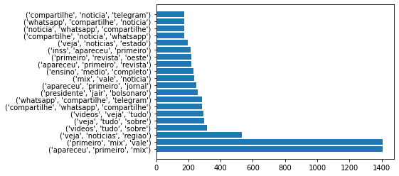

```python
mostrar_ngrams_frequentes(noticias_df, 'resumo', 3)
```

## Análise dos textos quanto ao tamanho

### Título

#### Histograma do título

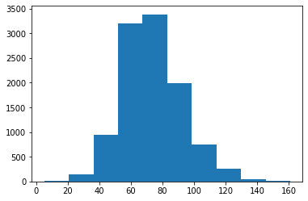

```python
mostrar_histograma(noticias_df, 'titulo')
```

Não parece haver uma variação de tamanho muito discrepante entre os títulos. Para confirmar, analisar os títulos cujo tamanho está nas faixas extremas do histograma:

#### Títulos muito curtos

```python
mostrar_registros_com_tam_menor_q(noticias_df, 'titulo', 21)
```

```
1244           Despreparados
2454                   Posse
2453                 Resgate
5000       Junto e misturado
6690           Pula fogueira
7027        Direitos no INSS
7445     ECD: dúvidas comuns
7502         O que é a Otan?
7586         Herói em Cannes
8305                  Aurora
8695        Nióbio rejeitado
8857      Flores permanentes
9338     Tommy: delírio rock
10497          País Dividido
Name: titulo, dtype: object
```

Realmente parecem apenas títulos curtos legítimos. Seria proveitoso apenas verificar do que se tratam as matérias cujo título tem apenas uma palavra:

```python
noticias_df[noticias_df['titulo'].isin(['Posse', 'Resgate', 'Aurora'])]
```

|  | _id | id | fonte | titulo | resumo | link | data_publ | img | ignorar | titulo_preparado | titulo_preparado_str | resumo_preparado | resumo_preparado_str | tamanho_titulo |
| --- | --- | --- | --- | --- | --- | --- | --- | --- | --- | --- | --- | --- | --- | --- |
| 2454 | 629cf068011b744cc508cf02 | https://noticias.uol.com.br/ultimas-noticias/afp/2022/05/07/posse.htm | UOL | Posse | Paris, 7 Mai 2022 (AFP) - Emmanuel Macron recebe a faixa da Ordem Nacional da Legião de Honra da França no palácio presidencial do Eliseu em Paris, em 7 de maio de 2022 | https://noticias.uol.com.br/ultimas-noticias/afp/2022/05/07/posse.htm | 2022-05-07 21:03:00 |  | False | [posse] | posse | [paris, mai, afp, emmanuel, macron, recebe, faixa, ordem, nacional, legiao, honra, franca, palacio, presidencial, eliseu, paris, maio] | paris mai afp emmanuel macron recebe faixa ordem nacional legiao honra franca palacio presidencial eliseu paris maio | 5 |
| 2453 | 629cf068011b744cc508cf01 | https://noticias.uol.com.br/ultimas-noticias/afp/2022/05/07/resgate.htm | UOL | Resgate | Havana, 7 Mai 2022 (AFP) - Ruínas do Saratoga Hotel, após uma explosão na véspera, em Havana, em 7 de maio de 2022 | https://noticias.uol.com.br/ultimas-noticias/afp/2022/05/07/resgate.htm | 2022-05-07 21:06:00 |  | False | [resgate] | resgate | [havana, mai, afp, ruinas, saratoga, hotel, apos, explosao, vespera, havana, maio] | havana mai afp ruinas saratoga hotel apos explosao vespera havana maio | 7 |
| 8305 | 629cf068011b744cc508e5dc | https://gamarevista.uol.com.br/cultura/trecho-de-livro/aurora/ | UOL | Aurora | <img align="left" src="https://conteudo.imguol.com.br/c/parceiros/96/2022/05/20/reproducao--gama-revista-1653047931796_v2_142x100.jpg" /> Apesar de suas pinturas terem passado por exposições em grande… | https://gamarevista.uol.com.br/cultura/trecho-de-livro/aurora/ | 2022-05-20 13:00:00 |  | False | [aurora] | aurora | [apesar, pinturas, terem, passado, exposicoes, grandes, museus, centros, culturais, brasileiros, masp, mar, rio, janeiro, paris, aurora, cursino, santos, nunca, protagonizou, exposicao, individual, al… | apesar pinturas terem passado exposicoes grandes museus centros culturais brasileiros masp mar rio janeiro paris aurora cursino santos nunca protagonizou exposicao individual alvo estudos exclusivamen… | 6 |

**Decisão:** manter todas essas matérias, pois parecem legítimas

#### Títulos muito longos

```python
mostrar_registros_com_tam_maior_q(noticias_df, 'titulo', 140)
```

```
197                       Vídeo mostra brasileiros suspeitos de tráfico internacional de drogas na Tailândia com suposta aliciadora em aeroporto antes de embarque, diz PF
464        Paranaense preso por tráfico de drogas na Tailândia telefona aos pais após dois meses: 'Pediu que mandasse uma Bíblia, para que pudesse refletir', diz advogado
2419                  Avó descobre tortura contra filha e neto de 3 anos após receber localização e resgatá-los em outra cidade: 'Queimaram as genitais dele com isqueiro'
2812                         Nº de MEIs cresce 80,8% em 5 anos em Piracicaba, aponta Sebrae; veja como abrir o negócio e bolsa, linha de crédito e assessorias disponíveis
2963                Golpistas usam dados de empresas que estão nas redes sociais e se passam por integrantes de facção criminosa para tentar extorquir dinheiro de vítimas
192             GUERRA NA UCRÂNIA: ONU anuncia segunda retirada de civis em Mariupol; Kiev acusa Rússia de romper promessa e invadir último ponto de resistência na cidade
4973                       Estoque, entrega, frete, logística: o que o pequeno empresário precisa saber para oferecer uma boa experiência ao cliente e não perder dinheiro
5173         Brasileiros presos na Tailândia: após condenação de Mary Hellen, defesa de Jordi espera pena igual ou menor em julgamento por tráfico internacional de drogas
6047                       'Após término com ex-noivo, dei uma chance para o amor e tive sucesso', diz mulher que decidiu fazer festa de 'descasamento' para evitar multas
6793      Com nova operação no sistema de água e esgotos, Águas do Nordeste (ANE) investirá R$ 260 milhões em obras de abastecimento e esgotamento sanitário em Santa Rita
6874                         'Não abrimos mãos dos princípios e valores da palavra de Deus', diz pastor de igreja de Aracaju onde fiel afirma ter sido vítima de homofobia
7899                         A médica holandesa que diz que continuará enviando pílulas abortivas a mulheres nos EUA mesmo se direito a interromper gravidez for derrubado
7803                     Campinas tem 15% dos alunos de 4º e 5º anos com alfabetização prejudicada pela pandemia, e defasagem em matemática chega a 40% entre 6º e 7º anos
8750                       É estável quadro de adolescente de 14 anos submetida a transplante de fígado por suspeita de hepatite grave de causa desconhecida, diz hospital
8931                         Profissão Repórter mostra a rotina de risco de atletas do ciclismo de estrada, que dividem espaço com veículos em alta velocidade nos treinos
9533                         Fila por vaga em UTI infantil: bebês de 1 mês aguardam há dias por leito e mães denunciam falta de cirurgião pediátrico em hospital no Recife
10489    Você viu? Operação da Vila Cruzeiro, massacre em escola nos EUA, acidente com influenciador e cachorro, morte após abordagem da PRF, padre avô e Pix transfer-IDO
Name: titulo, dtype: object
```

**Decisão:** Todas essas parecem matérias legítimas, sem necessidade de intervenção

### Resumo

#### Matérias sem resumo

```python
len(noticias_df[noticias_df['resumo'] == ''])
```

```
592
```

```python
len(noticias_df[noticias_df['resumo'] == None])
```

```
0
```

```python
len(noticias_df[noticias_df['resumo'].isnull()])
```

```
0
```

Pelos comandos acima, verifica-se que há um número considerável matérias com resumo vazio. O impacto disso terá de ser obvervado ao se avaliar a execução dos algoritmos de machine learning.

#### Histograma do resumo

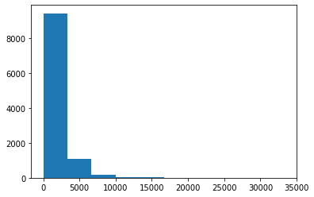

```python
mostrar_histograma(noticias_df, 'resumo')
```

A grande maioria dos resumos tem tamanho menor que 3500 caracteres. Percebe-se uma amplitude considerável nos tamanhos dos resumos. Ou seja, há uma variação muito grande na quantidade de informação contida nos resumos. Assim como mencionado com relação à ausência do resumo, o impacto dessa variação terá de ser obvervado ao se avaliar a execução dos algoritmos de machine learning.